# Machine Learning Project - Human Activity Recognition

## Introduction:

This is the final project of the Practical Machine Learning course.

The goal is to analyse data collected from subjects going dumbell exercises, and use the data to compile a prediction method for whether someone is exercising the right way or not. More info here: http://web.archive.org/web/20161224072740/http:/groupware.les.inf.puc-rio.br/har

## Preparations:

The loading of packages is not displayed in the interest of space. Packages loaded are the following: caret, ggplot2, dplyr, corrplot, plot3D

The following code reads in the data and cleans it up somewhat.

```r
# Get the training and testing data
dataUrlTrain <- "https://d396qusza40orc.cloudfront.net/predmachlearn/pml-training.csv"
dataUrlTest <- "https://d396qusza40orc.cloudfront.net/predmachlearn/pml-testing.csv"
#download.file(url=dataUrlTrain, destfile = "pmlTrain.csv")
#download.file(url=dataUrlTest, destfile = "pmlTest.csv")

# We checked beforehand which strings should be consider as "NA"
training <- read.csv("pmlTrain.csv", dec=".", sep=",", na.strings=c("NA","NaN", " ","", "#DIV/0!"))
testing <- read.csv("pmlTest.csv", dec=".", sep="," , na.strings=c("NA","NaN", " ","", "#DIV/0!"))


# Remove anything that has a NA or a blank
col.has.na <- apply(training, 2, function(x){any(is.na(x))})
train<- training[,!col.has.na]
col.has.blank <- apply(train, 2, function(x){any(x=="")})
train2<- train[,!col.has.blank]
```

## Exploratory graphs

We make a graph to see whether different subjects give clustering data.  
Then we make a similar graph but showing classe instead of user name. We use only the arm movements for illustration.

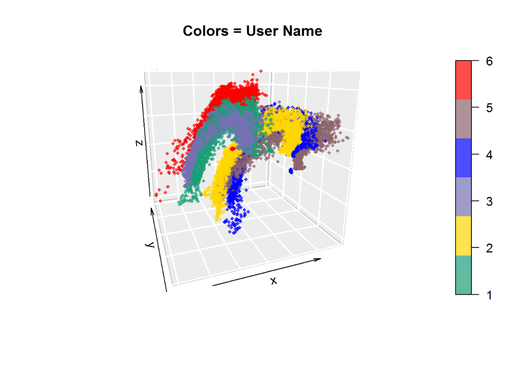

```r
scatter3D(train2$accel_arm_y, train2$accel_arm_x, train2$accel_arm_z,
          colvar=as.integer(train2$user_name),
          col = c("#1B9E77", "gold", "#7570B3", "blue","pink4","red"),alpha=0.7,
          labels = c("adelmo", "carlitos","charles","eurico","jeremy", "pedro"),
          theta=-20, phi=15, bty="g", pch=18, cex=0.7,
          main ="Colors = User Name")
```

This graph clearly shows that each subject generated a different “cluster” of points. This suggests that we should probably *center* and *scale* our data to correct for subject bias.

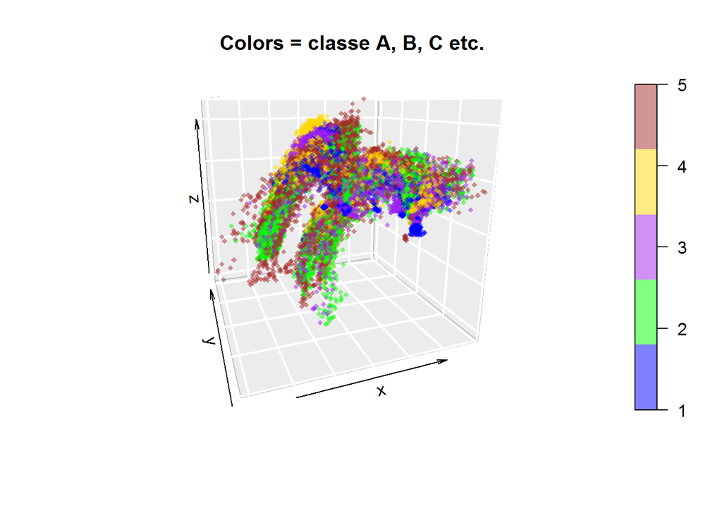

```r
# But classes are not really clustered into groups
scatter3D(train2$accel_arm_y, train2$accel_arm_x, train2$accel_arm_z,
          colvar=as.integer(train2$class),
          col = c("blue", "green", "purple", "gold","brown"), alpha=0.5,
          theta=-20, phi=15, bty="g", pch=18, cex=0.7 ,
          main ="Colors = classe A, B, C etc.")
```

In contrast, the second graph shows no discernable pattern of classe, suggesting we do need a fancy algorithm for this task.